# 第1回 イントロダクション／情報検索と Excel の基本

経済データ入門

第1回

イントロダクション／情報検索  
と Excel の基本

確かめられる数字だけが、根拠になる

経済データ入門

第1回 — Topic01

統計データの出所と出典の明示

その数字は誰のものか

## この回の道のり

1

出所と出典

2

画面と構造

演習 1-2

24 個をテーブルに

3

集計と参照

演習 1-3

2 通りで照合

4

可視化と検証

演習 1-4

線と言葉と突き合わせ

いまここ — 数字の身元を言える型を、Excel を触る前に手にする

## この授業で何ができるようになるか

- **出どころをたどれる**：その数字が誰の・何の統計かを言える
- **自分の手で出せる**：同じ数字を 2 通りの道で出して照合
- **突き合わせられる**：AI の答えを、自分のシートと出典で検収
- **言葉にできる**：グラフの動きを 1 行で説明。限界も明記

確かめられる数字だけが、根拠になる

## このトピックで身につけるもの

- **データ取得先の地図**：欲しい数字がどの系統にありそうかの見当
- **2 つの入口**：e-Stat は 4 つ、EDINET は 3 つの手順でたどれる
- **出典 4 点セット**：作成機関・統計名と調査年・表名・取得日
- **データカード**：数字の身元を 7 項目に書き写す型

この型は、以後どの回でもいちばん最初にやること

## 印象では決まらない

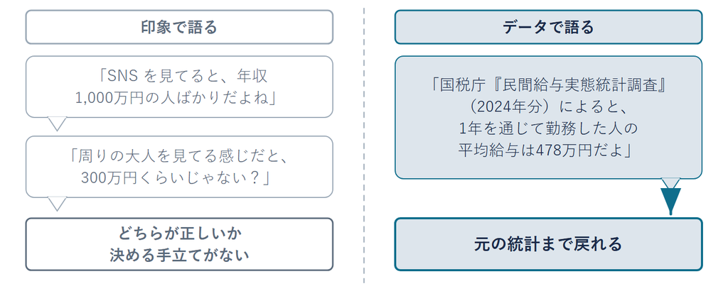

「SNS で見た」「周りを見ると」は、どちらも印象。元の資料まで戻れる一言だけが違う

## Excel の前に、数字の身元を言える型を持つ

宣言 この回は、**数字の身元を言える型**を先に手にしてから Excel を触る

- **なぜ先か**：身元の分からない数字を速く集計しても、根拠にならない
- **どこで使うか**：以後の回は毎回このトピックから  
  始まり、書くのは同じ 1 枚
- **いつ必須か**：レポートで数字を出すときは  
  この 1 枚に記録すれば、漏らさず出典が書ける

型は 2 つだけ — 出典 4 点セットと、データカード 7 項目

## 3 つとも正しいのに、食い違う

| 統計名（作成機関） | 何の平均か | 数字（年次） |
| --- | --- | --- |
| 民間給与実態 統計調査 （国税庁） | **1 年を通じて勤務した** 給与所得者 1 人の年間給与 | 478 万円 （2024年分） |
| 賃金構造基本 統計調査 （厚生労働省） | **一般労働者（男女計）** 1 人の所定内給与額・**6 月分** | 330,400 円 （2024年） |
| 家計調査 （総務省統計局） | **二人以上の世帯**のうち勤労者世帯 1 世帯の月の実収入 | 636,155 円 （2024年平均） |

年は 3 つとも 2024 年でそろえた（国税庁の最新が 2024 年分のため）  
収入に関する 3 つの統計。年額と月額、1 人と 1 世帯が混ざっている

## 数えているものが違う

賃金構造の月額を 12 倍する  
330,400 × 12 ＝ **3,964,800 円**  
約 396 万円

国税庁の 478 万円と比べる  
478 万円 − 約 396 万円 ＝ **約 82 万円**  
約 1.2 倍の開き

- **6 月の 1 か月分**：賃金構造の数字は、残業代も賞与も入らない金額
- **家計調査は別の話**：3 つ目は 1 世帯の月収で、1 人の年収とは比べない
- **正しさの問題ではない**：どれも正しく、比べ方が間違っている

だから「どの統計の、何の平均か」を書き留める

## データ取得先の世界地図

| # | 系統 | 取得先 | 何があるか |
| --- | --- | --- | --- |
| 1 | 政府統計の窓口 | **e-Stat** | 各府省の統計を 1 か所に |
| 2 | 統計の元締め | 総務省統計局 | 国勢・労働力・家計・物価 |
| 3 | 各省庁 | 厚労・経産・財務・内閣府 | 賃金・商業・金利・GDP |
| 4 | 中央銀行 | 日本銀行 | 金利・為替の時系列 |
| 5 | 企業 | **EDINET**・JPX・各社 IR | 有価証券報告書・決算 |
| 6 | 地域 | RESAS | 地域の産業・人口・観光 |
| 7 | 練習用 | SSDSE | 整えられた表 |
| 8 | 観測 | 気象庁 | 月平均気温 |
| 9 | 国際機関 | World Bank・IMF・OECD | 国際比較と各国の時系列 |
| 10 | 横断検索 | Dataset Search・NDL | 一次ソースまで遡る |

覚えなくてよい。**作った人から当てて入る**。太字の 2 つをこのあとたどる

## e-Stat の 4 つの手順

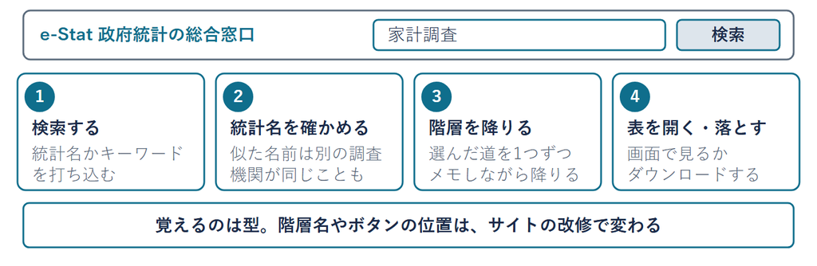

検索する → 統計名を確かめる → 階層を降りる → 表を開く。  
**どこを選んだかをメモしながら降りる**

## 表の背番号 — 統計表 ID

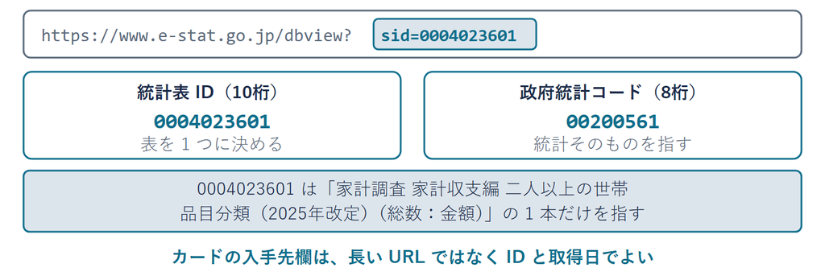

同じ統計の中に表は何十本もある。**どの表か**を一意に指すのが統計表 ID

## EDINET の 3 つの手順

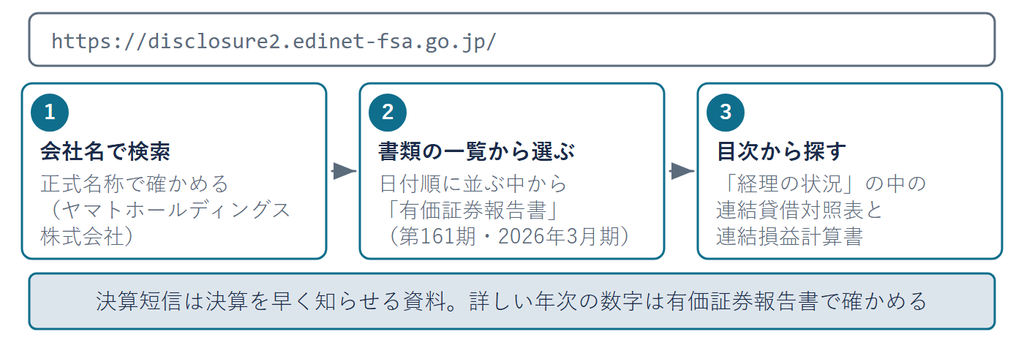

金融庁の EDINET で、会社名 → 書類の一覧 → 「経理の状況」。  
有価証券報告書は年 1 回の開示

## 一次ソースと二次ソース

用語 **一次ソース**＝調べた本人が公表したもの／  
**二次ソース**＝誰かがそれを読んで書いたもの

- **一次の例**：国税庁の公表表、統計局の統計表、会社の有価証券報告書
- **二次の例**：ニュース記事、まとめサイト、教科書、**生成 AI の回答**
- **使い分け**：二次ソースは入口にしてよいが、  
  根拠にするのは遡れたときだけ

「〜調査によると」と書いてあったら、その調査まで戻れるかを試す

## 出典 4 点セット

型 作成機関「統計名（調査年）」表名、〔取得日〕取得

- **作成機関**：誰が作ったか。省庁名・機関名を正式名で
- **統計名と調査年**：どの統計の、いつの調査か
- **表名**：統計の中のどの表か。統計表 ID を添えるとなお良い
- **取得日**：自分がそのページを開いた日。  
  **伝えなければ AI には分からない**

完成例（このあと Excel に入れる表）：経済産業省「商業動態統計調査（2024年・2025年）」  
百貨店・スーパー商品別販売額、2026-09-22 取得

図表を出したら、そのすぐ下にこの 1 行を置く

## 数字は公表のあとも動く

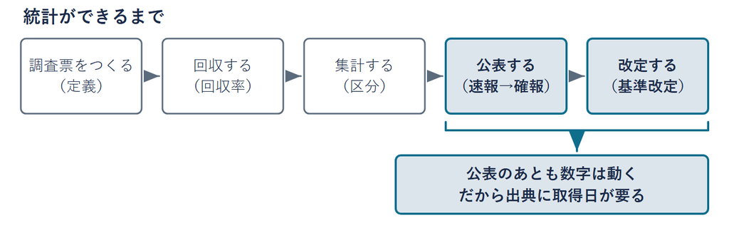

速報が確報に替わる統計もある。基準改定で過去も動く。だから取得日が要る

## データカード 7 項目

| 項目 | 民間給与実態統計調査の例 |
| --- | --- |
| 統計名・表番号 | 民間給与実態統計調査 — 第3表 給与階級別の総括表 |
| 作成機関 | 国税庁 |
| 調査の種類 | 標本調査・民間の事業所と給与所得者が対象・毎年 |
| 単位・基準 | 万円／年・1 人あたり・名目値（物価の変化を調整しない金額） |
| 定義の落とし穴 | 「1 年を通じて勤務した」人の平均。民間のみで公務員は入らない |
| 入手先・取得日 | 公表ページの URL・開いた日 （政府統計コード 00351000 は**表の ID ではない**） |
| 出典 4 点セット | 国税庁「民間給与実態統計調査（2024年分）」 第3表 給与階級別の総括表、〔取得日〕取得 |

〔取得日〕は自分が開いた日を書く。この 7 項目が、学期を通したデータ台帳の型

## 3 つの軸 — 調査の種類の見分け

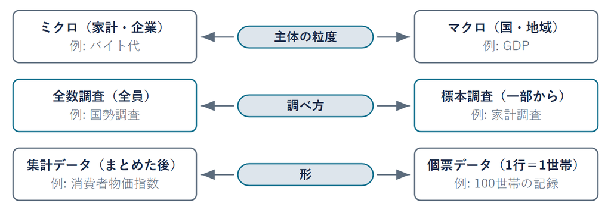

ミクロかマクロか・**全数か標本か**・集計か個票か。カードの 1 行に書くための見分け

## つまずきと手当て

- **Q**：ニュースの数字をそのまま根拠にしてよいか
  - **A**：「〜調査によると」から**遡れたら使える、遡れなければ使わない**
- **Q**：取得日は書かなくても困らないのでは
  - **A**：半年後に同じ表を開くと数字が違うことがある。  
    速報から確報への置き換えが起きる
- **Q**：「1 年を通じて勤務した」の限定は落としてよいか
  - **A**：落とした瞬間に別の数字になる。限定ごと書き写す
- **Q**：似た名前の統計をどう見分けるか
  - **A**：家計調査・家計消費状況調査・全国家計構造調査は  
    別物。**統計表 ID を書き留める**

## まとめ

- **データ取得先の地図**：欲しい数字がどの系統にありそうか見当を付ける
- **2 つの入口**：e-Stat は 4 つ、EDINET は 3 つの手順でたどる
- **出典 4 点セット**：作成機関・統計名と調査年・表名・取得日を 1 行に
- **数字は動く**：速報から確報へ替わる。だから取得日を書く
- **データカード 7 項目**：定義の落とし穴まで書き写し、数字の身元を残す

データカードの書き方は、あとで中間レポートで使う  
次のトピックでは、**身元の分かった数字を Excel に入れる**

経済データ入門

第1回 — Topic02

Excel の基本構造とセル参照

画面に名前を付けて、表をテーブルにする

## この回の道のり

1

出所と出典

2

画面と構造

演習 1-2

24 個をテーブルに

3

集計と参照

演習 1-3

2 通りで照合

4

可視化と検証

演習 1-4

線と言葉と突き合わせ

いまここ — 身元の分かった数字を、Excel の上に置く

## 前のトピックで手に入れた型

前トピックのポイント — 統計データの出所と出典の明示

Q: これから入力する 24 個は、誰の・何の統計か

- **出典 4 点セット**：作成機関・統計名と調査年・表名・取得日
- **データカード 7 項目**：統計名から出典の 1 行まで、上から埋める
- **この 24 個**：経済産業省「商業動態統計調査」・スーパーの販売額・億円

カードはもう 1 枚書かない。ここからは、この数字を Excel に載せる

## このトピックで身につけるもの

- **画面を名前で指す**：ブック・シート・セル番地・数式バー・リボン
- **「=」の掟を読む**：先頭の「=」で、式か文字かが決まる
- **表の骨組みを作る**：見出し → オートフィル → 24 個
- **テーブルにする**：`Ctrl + T` と、そこで変わる 4 点

この回の到達点は、表が「ひとまとまりのデータ」になっていること

## 電卓で足りる仕事、Excel が要る仕事

宣言

ここで作るのは、  
**1 マス直すと合計も平均もグラフも追いかける**状態

- **なぜ先か**：12 個を足すだけなら、電卓のほうが速いこともある
- **どこで差がつくか**：**数字を直したとき**。電卓は最初からやり直し
- **いつ必須か**：数字が増えるとき・直すとき・人に見せるとき

速さで選ぶ道具ではない。**直せること**で選ぶ道具

## 画面に名前を付ける

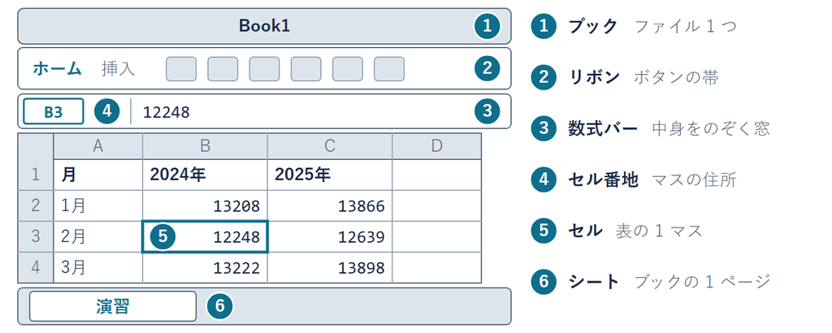

名前で指せれば人に訊けるし、手順書も読める。まずはこの 6 つ

## 6 つの部品の呼び名

| 用語 | 何か | 身近なたとえ |
| --- | --- | --- |
| ブック | Excel のファイル 1 つ | 1 冊のノート |
| シート | ブックの中の 1 ページ | ノートのページ |
| セル | 表を区切る 1 マス | 方眼紙の 1 マス |
| セル番地 | マスの住所（列 ＋ 行） | 「◯列◯行」という住所 |
| 数式バー | 選んだセルの中身を出す欄 | 中身をのぞく窓 |
| リボン | 画面上部のボタンの帯 | 道具箱のふた |

セルに見えているのは**答え**で、本当の中身は数式バーにある

## 行と列とセル番地

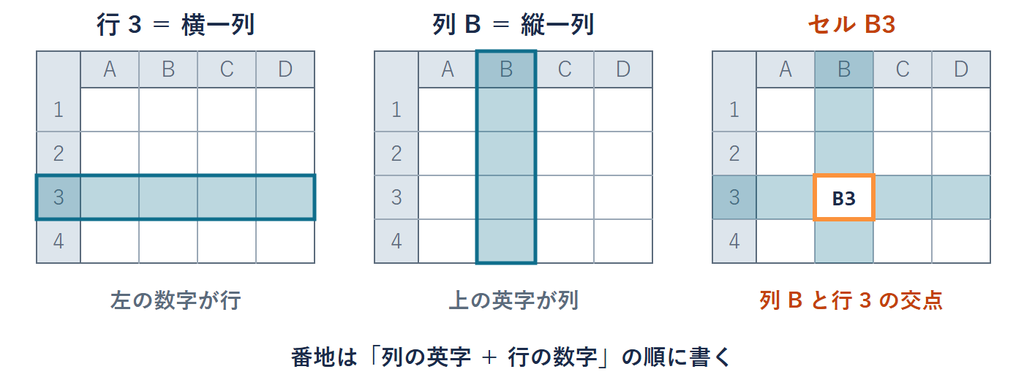

行は**横一列**、列は**縦一列**。2 本が交わる 1 マスに、番地が 1 つ付く

## セルへの入力と直し方

決め

**行は横一列、列は縦一列**。列 B と行 3 が交わるマスは **セル B3**

- **入れる**：セルをクリック → 打つ → `Enter` で確定
- **直す**：ダブルクリック、または数式バーで書き換える
- **戻す**：`Ctrl + Z`（Mac では `⌘ + Z`）。戻せない操作もある
- **保存する**：`Ctrl + S`（Mac では `⌘ + S`）

「行＝横一列・列＝縦一列」は、以後どの回でも説明なしに使う

## セルの書式設定は 3 つの道で開く

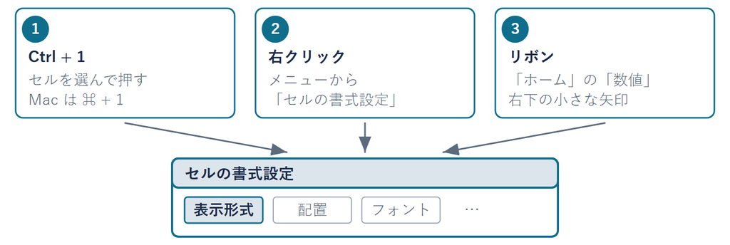

どれでも同じ画面が開く。1 つ覚えておけばよく、忘れたら別の道で行ける

## 「=」の掟

掟

セルへの入力は、**先頭が「=」なら計算式**。  
そうでなければ**ただの文字か数値**

- **確定すると答え**：ふつうはセルに答え。式は数式バーで見る
- **演算子は 4 つ**：`+` `-` `*` `/`。掛け算・割り算に `×` `÷` は使わない
- **ここが心臓**：Excel でできることは、ほとんど全部この 1 行から始まる

覚える掟は 1 つだけ

## 数式バーの位置

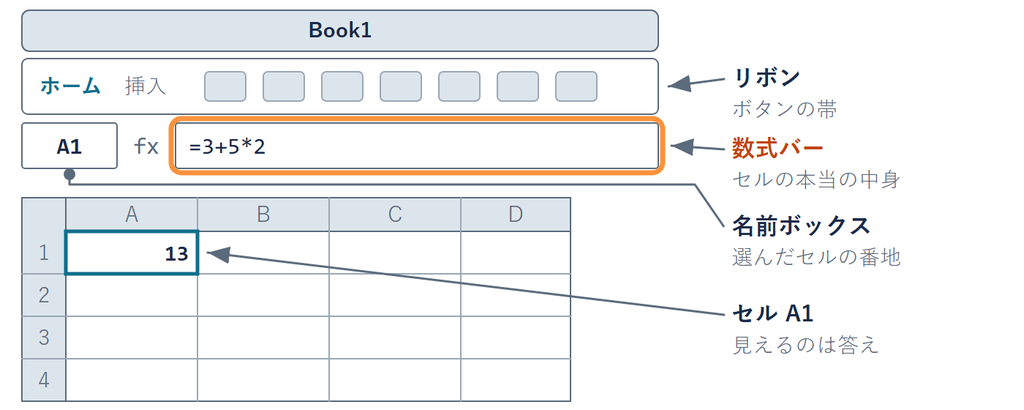

A1 を選ぶと、数式バーには式 `=3+5*2`、セルには答えの 13 が出る

## 同じ文字列が、式にも文字にもなる

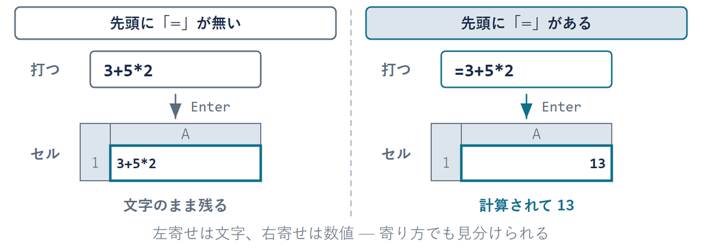

左は「=」が無いので文字がそのまま残る。**計算されない**のは壊れたからではない

## 計算の順序 — 13 と 16

かっこが無い  
`=3+5*2` → **13**  
掛け算が先

かっこがある  
`=(3+5)*2` → **16**  
かっこの中が先

- **算数と同じ**：掛け算・割り算が、足し算・引き算より先
- **迷ったらかっこ**：先に計算したい部分を囲む
- **確かめ方**：セルに打ち、数式バーと見比べる

順序を変えたいときは、かっこで囲む

## オートフィルで 1月 から 12月

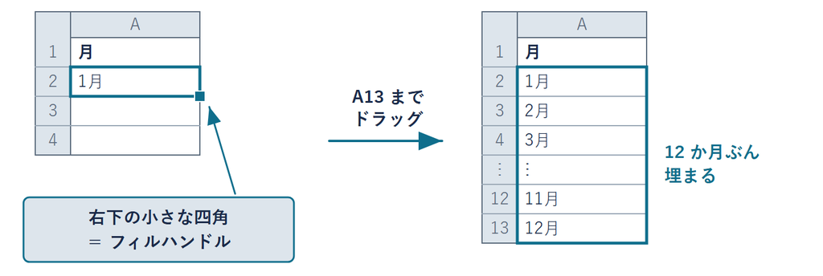

規則を読み取って埋める。手で 12 回打つのは、間違いを 12 回作る道

## 表の骨組みの作成

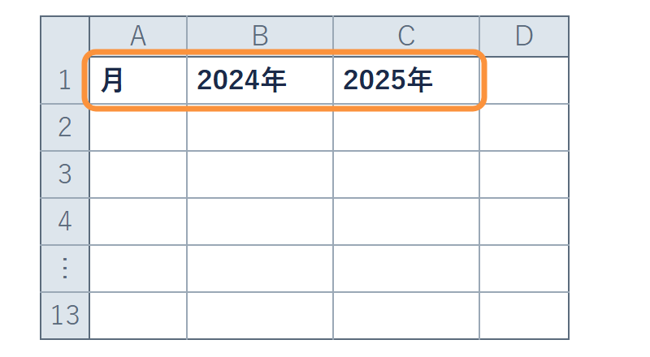

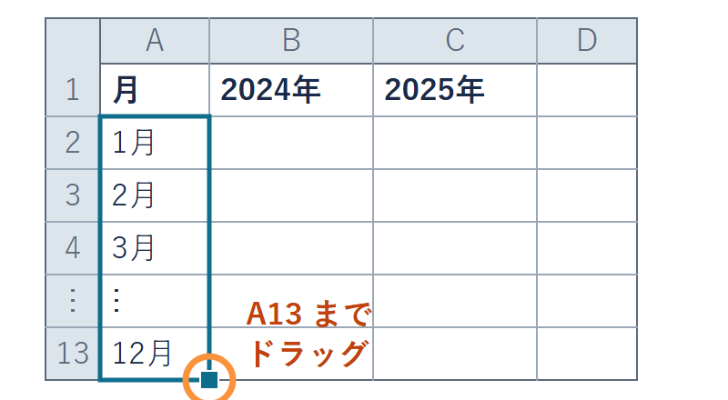

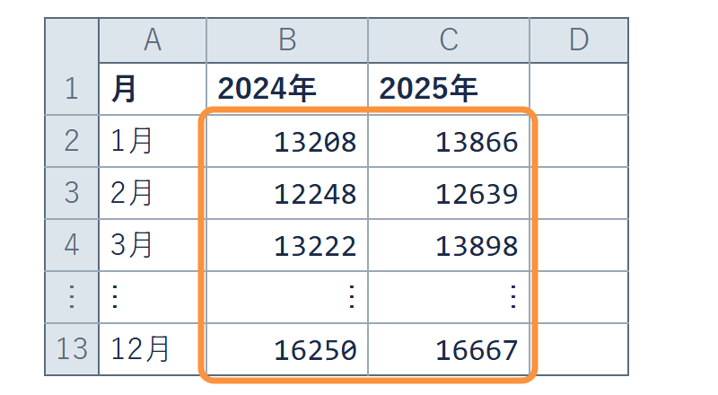

1 行目に空欄を作らない。ここが**列の名前**になる

## 範囲のテーブル化

宣言

新しいデータを手にしたら  
まず **`Ctrl + T`**（Mac では **`⌘ + T`**）

- **何が起きるか**：範囲が「テーブル」というまとまりになる
- **なぜ先に**：この授業では、**列を名前で指し、式を自動で広げる**ため
- **手順**：次のページで、画面を見ながら 3 つの STEP で

見た目は色が付くだけ。中身は 4 つ変わる

## テーブルへの変換手順

1. 表の中のセルを **1 つ**選ぶ
2. **Ctrl + T**  
   （Mac では **⌘ + T**）  
   範囲と見出しの  
   印を確認
3. **OK** を押す。  
   見出しに色と ▼ が付く

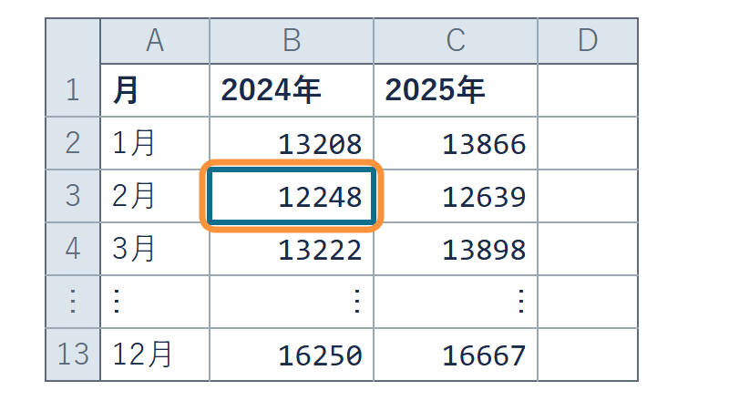

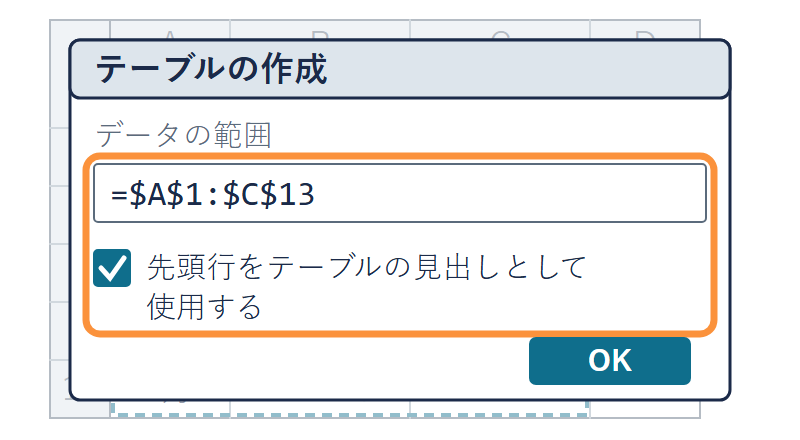

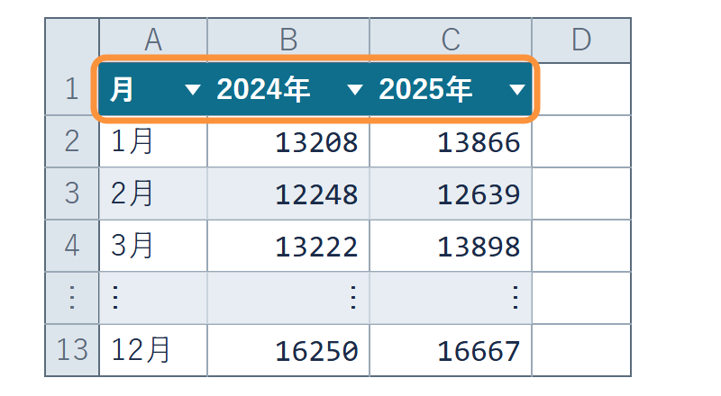

範囲は `=$A$1:$C$13`。見出しの印が付いていなければ付けてから OK

## テーブルにすると 4 点変わる

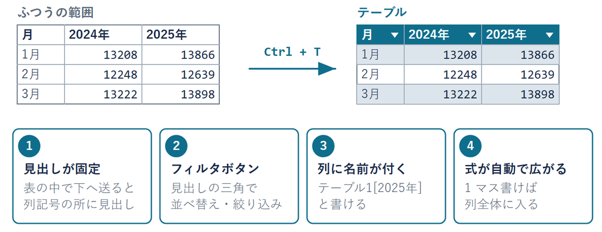

いちばん効くのは 3 つめ。**番地は場所しか伝えないが、名前は中身を伝える**

## Q&A

Q1 右下の四角を引いたら、1月 が下へ動いただけだった

つかんだのが**枠の線**。`Ctrl + Z` で戻し  
ポインタが細い **＋** に変わる右下の四角を引く

Q2 見出しの 1 行目に空欄があるとどうなるか

Excel が勝手に「列1」と名付ける。**空欄を作らない**  
「列1」が付いたら、見出しセルを正しい名前に書き換える

Q3 数字を入れたのに合計に足されない

**文字のまま入っている**。緑の三角から「数値に変換する」

Q4 `Ctrl + T` のダイアログはそのまま OK でよいか

**範囲と見出しの印の 2 つだけ**は目で確かめてから OK

## 演習 1-2 — 24 個を入れてテーブルにする

演習 1-2

表の骨組みを作り、`Ctrl + T` でテーブルにする

演習番号は「回-トピック」。今回 1-1 はなし

✋ 動画を止めて 8 分。テーブルになったら再生に戻る

この表はもう、ひとまとまりのデータ。次は合計と平均を 2 通りで出して照合する

経済データ入門

第1回 — Topic03

集計関数と相対参照

合計と平均を 2 通りで出して照合する

## この回の道のり

1

出所と出典

2

画面と構造

演習 1-2

24 個をテーブルに

3

集計と参照

演習 1-3

2 通りで照合

4

可視化と検証

演習 1-4

線と言葉と突き合わせ

いまここ — テーブルにした 24 個から、合計と平均を出す

## 前のトピックで作った表

前トピックのポイント — Excel の基本構造とセル参照

Q: いま手元の表は、どんな状態か

- **3 列（月・2024年・2025年）の表**：A 列に 1月〜12月、B・C 列に 24 個
- **テーブルになっている**：`Ctrl + T` で、列に名前が付いた
- **「=」の掟**：先頭が「=」なら計算式。そうでなければ文字か数値

この表から、まず 2025年の合計と平均、最後に前年との差を出す

## このトピックで身につけるもの

- **2 通りで出す**：集計行（ツール）と、その真下に書く関数
- **照合する**：2 つの答えが一致するかを、自分で確かめる
- **1 つ書いて広げる**：差の列と、コピーでズレる番地（相対参照）
- **見た目を整える**：桁区切り。変わるのは見た目だけ

このトピックの到達点は、ツールの答えを自分の式で確かめられること

## 合計と平均を、2 通りで出す

宣言

同じ数を**ツールと関数の 2 通り**で出し、**一致するか**を見る

- **何をやるか**：合計と平均を、集計行と関数の両方で出す
- **なぜ 2 通りか**：1 通りだけでは、出た数が正しいかを言えない
- **いつ必須か**：この先の道具も AI の答えも、確かめ方は同じ型

1 通りなら「出た」だけ。2 通りそろって「確かめた」

## 集計行の出し方

1. テーブル内のセルを選ぶ
2. **テーブルデザイン**の  
   **集計行**に印を入れる
3. C14 の **▼** で「合計」  
   168025 が出る

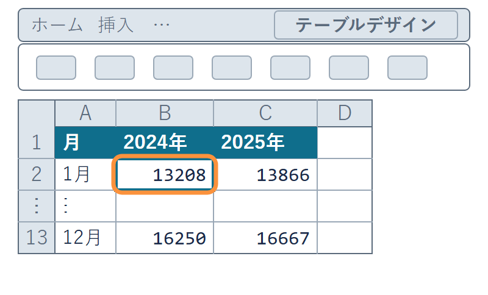

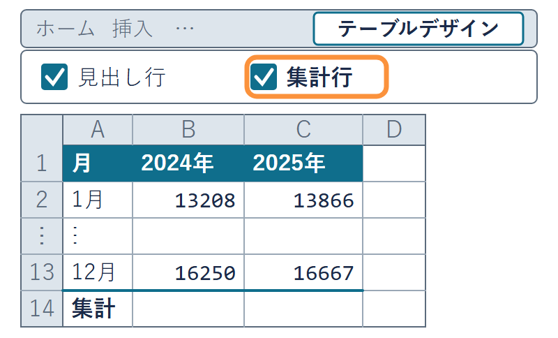

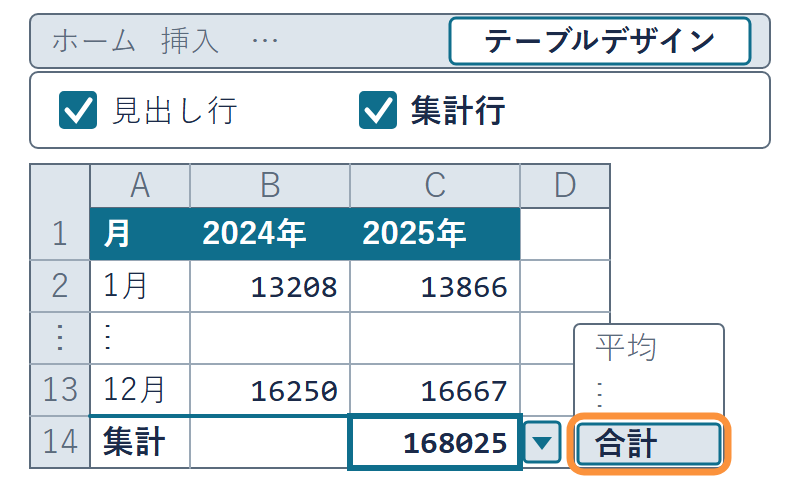

14 行目に「集計」の行。▼ で「平均」も選べる  
（小数第 2 位まで表示すると 14002.08）

## 関数の型 — `=関数名(引数)`

型

`=関数名(引数)`。使うのは **SUM**（合計）  
と **AVERAGE**（平均）の 2 つ

- **引数**（ひきすう）：関数に渡す材料。たいていは**セルの範囲**
- **SUM**：`=SUM(C2:C13)` は「C2 から C13 までを全部足す」
- **AVERAGE**：平均を出す。この授業では **平均 ＝ 合計 ÷ 個数**

関数も「=」で始まる式。掟はそのまま効く

## 範囲指定のコロン

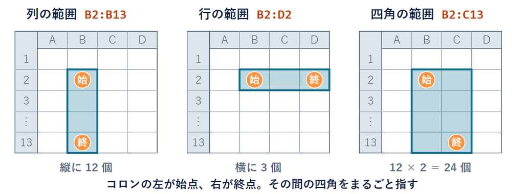

テーブルの列を選ぶと `テーブル1[2025年]` の形で入る（構造化参照）

## 関数の挿入による合計

1. 集計行の 2 つ下  
   「関数で合計」の **C16**
2. **fx** を押す
3. 一覧から **SUM**
4. **OK** で引数の画面へ
5. 2025年の列をドラッグ
6. **OK** で C16 に合計

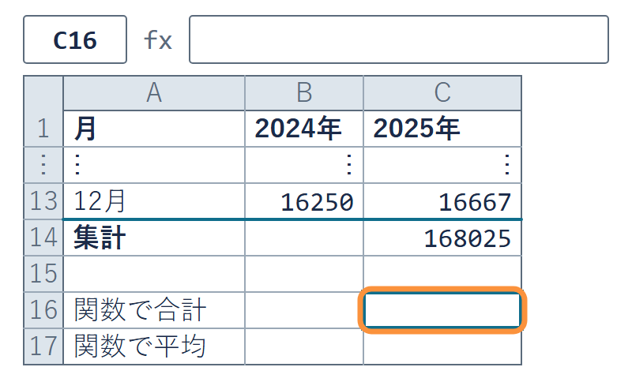

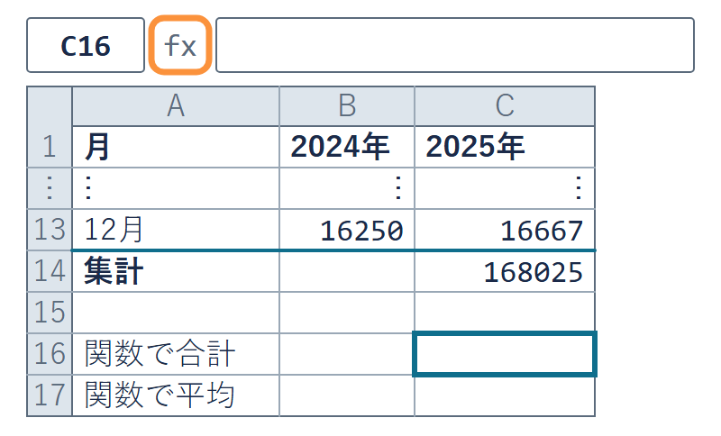

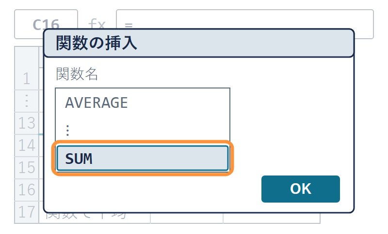

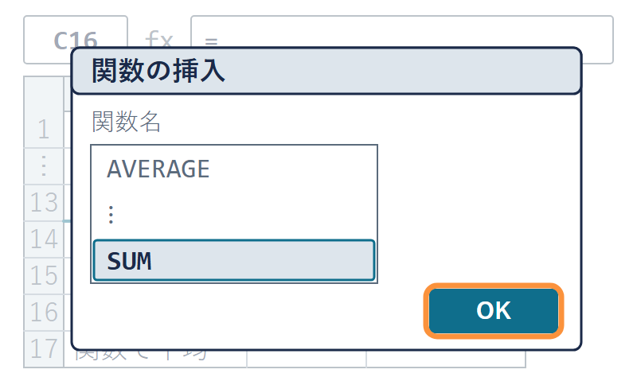

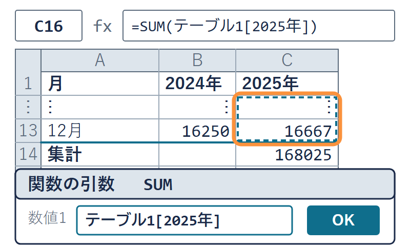

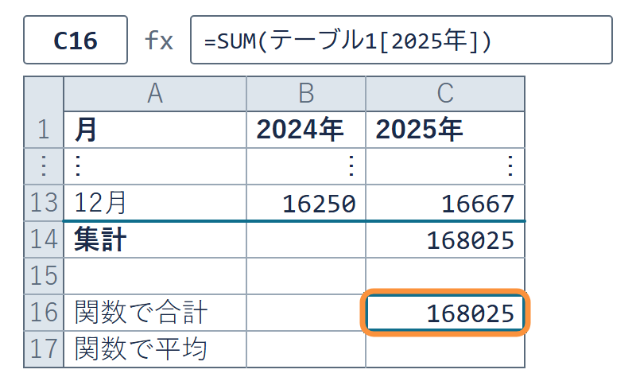

上は **Windows** の手順。Mac は［数式ビルダー］  
で SUM をダブルクリック → 範囲 → ［完了］  
**テーブル1 は例**で、表ごとに名前が違う